# Lesson 4. GIS Data Extraction in R: Habitat Fragmentation Metrics

L Leston

2023-07-06

**Introduction**

In previous lessons, we discussed the advantages and disadvantages of broad types of GIS data - Shapefiles or *vector data*, and *raster data*, and how to extract each type of data to survey points. Until recently, shapefile data was generally available at finer resolution than raster data, but increasingly raster data is available at finer spatial, spectral, and temporal resolution, especially on platforms like Google Earth Engine.

We might also consider taking detailed shape-file data and *rasterizing* it (converting it to a raster layer based on the values of a particular attribute in the polygons). Once the data is rasterized, we can calculate many different metrics of *habitat fragmentation*, *habitat connectivity*, or *habitat pattern*, based on the adjacency of cells of same or different type.

**Learning Objectives**

We will use some of what we have learned about manipulating shapefile and raster data to obtain measures of habitat fragmentation and pattern for survey points. Such metrics have been used in many landscape ecology studies. The **landscapemetrics** package will be used to obtain metrics of habitat fragmentation used in landscape ecology studies.

**Learning Outcomes**

**Wild Trax data set: BU_Edge_Communities_2021-2022**

The BU Edge Communities 2021-2022 data set consists of recordings from ARU stations set up along short transects starting at different kinds of manmade edges in Alberta’s boreal forests. These edges are associated with either harvest of trees for timber or pulpwood or different types oil and gas footprint (seismic lines, pipelines, roads, well sites).

We will use the *landscapemetrics* package to obtain metrics of habitat pattern and fragmentation. Calculating these metrics is a form of raster analysis: where the habitat data are in the form of shapefiles (*sf objects*), we can use the *fasterize* package to create rasters from those shapefiles.

```r
#Get libraries
library(dplyr)
library(tidyr)
library(sf)
library(tidyverse)
library(ggspatial)
library(raster)
library(maptools)
library(rgdal)
library(sp)
library(terra)

#Get point count site and year
a<-Sys.time()
#data
buEdges<-read.csv("point counts/BU_Edge_Communities_2021-2022_main_report.csv", header=TRUE)
#R looks for data file in point counts folder in same directory as this R script. File address is a relative file path.
buEdges$Year<-substr(buEdges$recording_date_time,1,4)#extracts year
buEdges.SSYR<-unique(buEdges[,c("location","Year","project_id","latitude","longitude")])
#get rid of any points lacking coordinates
buEdges.SSYR<-buEdges.SSYR%>%
  filter(!is.na(latitude))%>%
  filter(!is.na(longitude))
#buEdges.SSYR<-buEdges.SSYR[!is.na(latitude),]   #in base R
#buEdges.SSYR<-buEdges.SSYR[!is.na(longitude),]  #in base R

ssyr.sf <- st_as_sf(x = buEdges.SSYR,
               coords = c("longitude", "latitude"),
               crs = "+init=epsg:4326 +proj=longlat +ellps=WGS84
+datum=WGS84 +no_defs +towgs84=0,0,0")


ssyr.sf<-st_transform(ssyr.sf, "+proj=tmerc +lat_0=0 +lon_0=-115 +k=0.9992 +x_0=500000 +y_0=0 +ellps=GRS80 +units=m +no_defs") #transform the points to same coordinate system as the harvest data (in meters) we will be importing next
b<-Sys.time()
print(b-1)
```

```
## [1] "2023-07-20 12:11:17 MDT"
```

```r
ssyr.sf
```

```
## Simple feature collection with 1594 features and 3 fields
## Geometry type: POINT
## Dimension:     XY
## Bounding box:  xmin: 188702.2 ymin: 5470907 xmax: 820182.6 ymax: 6572133
## CRS:           +proj=tmerc +lat_0=0 +lon_0=-115 +k=0.9992 +x_0=500000 +y_0=0 +ellps=GRS80 +units=m +no_defs
## First 10 features:
##      location Year project_id                 geometry
## 1  A-RD-10-56 2021        599 POINT (281433.9 5957875)
## 2  A-RD-12-49 2021        599 POINT (202613.2 6051351)
## 3  A-RD-19-48 2021        599 POINT (601282.5 6119355)
## 4   A-RD-20-1 2021        599 POINT (711278.9 6099111)
## 5  A-RD-21-18 2021        599 POINT (204452.8 6189199)
## 6  A-RD-22-22 2021        599 POINT (379967.5 6234745)
## 7  A-RD-23-18 2021        599   POINT (476123 6209151)
## 8  A-RD-29-28 2021        599 POINT (509563.6 6291165)
## 9  A-RD-30-35 2021        599 POINT (236314.6 6473908)
## 10 A-RD-31-35 2021        599 POINT (467177.9 6411360)
```

Now get the harvest data.

```r
#Get harvest shapefile
harvest<-st_read("footprint/harvest2019corr.shp")
harvest<-st_transform(harvest, "+proj=tmerc +lat_0=0 +lon_0=-115 +k=0.9992 +x_0=500000 +y_0=0 +ellps=GRS80 +units=m +no_defs")
```

This provincial harvest data is *theoretically* up to date as of 2019, keeping in mind that it’s a shape-file and such large shape-files may not be updated consistently everywhere. All of the point counts we are looking at are more recent than 2019, and after excluding points known to have recent harvest (2019 or later), all harvest blocks in the shape-file should already be present and accounted for at each point count station.

Clip the harvest shapefile data to a bounding box defined by the retention point counts.

```r
box<-ssyr.sf%>%st_bbox()
print("Bounding box of point counts:")
```

```
## [1] "Bounding box of point counts:"
```

```r
box
```

```
##      xmin      ymin      xmax      ymax
##  188702.2 5470906.7  820182.6 6572133.5
```

```r
box2<-harvest%>%st_bbox()
print("Bounding box of harvest shape-file polygons")
```

```
## [1] "Bounding box of harvest shape-file polygons"
```

```r
box2
```

```
##      xmin      ymin      xmax      ymax
##  177375.1 5425911.9  854622.9 6650732.9
```

```r
#slightly bigger bounding box for the point counts
box3 = c(xmin = 187000, ymin = 5469000, xmax = 822000, ymax = 6574000)
harvest.retn<-st_crop(harvest, box3)
print("Bounding box of clipped harvest, at least 1 km larger on all sides than bounding box for point counts")
```

```
## [1] "Bounding box of clipped harvest, at least 1 km larger on all sides than bounding box for point counts"
```

```r
harvest.retn%>%st_bbox()
```

```
##    xmin    ymin    xmax    ymax
##  187000 5469000  822000 6574000
```

Now import the *fasterize* and *landscapemetrics* libraries:

```r
library(fasterize)
#a faster version of raster::rasterize that works with sf objects
library(landscapemetrics)
```

Try working with a single point first. Create a landscape by clipping harvest within a certain distance, rasterizing that harvest, and classifying anything that isn’t harvest as a separate cover class.

```r
onepoint1kBuffer<-ssyr.sf%>%
  filter(location=="H-CC-10-1")%>%#gets a single location from a clear-cut
  st_buffer(1000)#creates a circular polygon with 1000-m radius around the point

harvest1k<-harvest.retn%>%
  st_crop(onepoint1kBuffer)#clips all harvest polygons to just those within the bounding box of the 1-km point buffer

print("Harvest shapefile clipped to 1 kilometer from point:")
```

```
## [1] "Harvest shapefile clipped to 1 kilometer from point:"
```

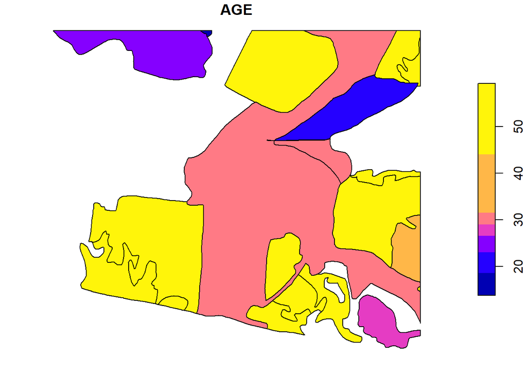

```r
#plot harvest areas within 1 km, showing year of harvest and age of harvest at time of point count
onepoint1kBuffer$Year<-as.integer(onepoint1kBuffer$Year)
harvest1k$AGE<-onepoint1kBuffer$Year-harvest1k$YEAR
plot(harvest1k["AGE"])
```

```r
r <- raster(onepoint1kBuffer, res = 10)
r <- fasterize(st_collection_extract(harvest1k, "POLYGON"), r, field = "AGE", fun="first")
#fun = how to combine overlapping polygons (there shouldn't be any).
#Currently takes "sum", "first", "last", "min", "max", "count", or "any".

print("Age of harvest blocks within 1 km at time of point count")
```

```
## [1] "Age of harvest blocks within 1 km at time of point count"
```

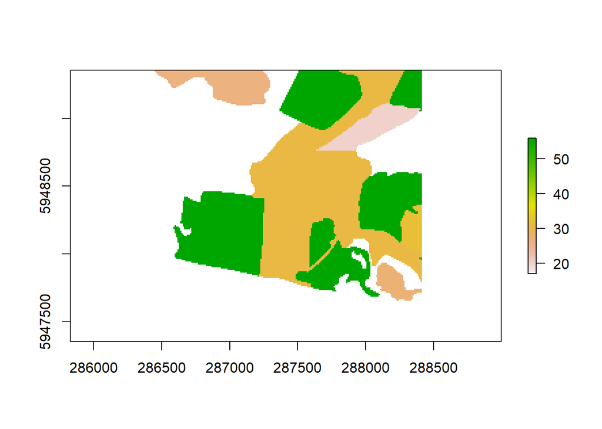

```r
plot(r)
```

```r
print("Specific harvest ages within 1 km of point count")
```

```
## [1] "Specific harvest ages within 1 km of point count"
```

```r
levels(as.factor(values(r)))
```

```
## [1] "17" "20" "26" "27" "31" "32" "56"
```

```r
#Create a single "cover class" for unharvested areas
r[is.na(r)]<-200
levels(as.factor(values(r)))
```

```
## [1] "17"  "20"  "26"  "27"  "31"  "32"  "56"  "200"
```

```r
r2<-r%>%
  crop(onepoint1kBuffer)%>%
  mask(onepoint1kBuffer)

print("Forest age classes within 1 km at time of point count (unharvested = 200)")
```

```
## [1] "Forest age classes within 1 km at time of point count (unharvested = 200)"
```

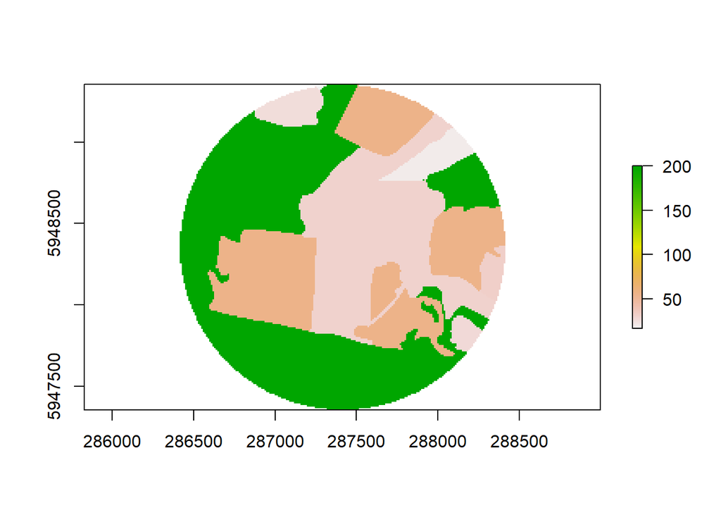

```r
plot(r2)
```

The oldest harvest within 1 km of the point count is 56 years old at the time of the point count.

Individual metrics in the *landscapemetrics* package can be calculated with functions at the patch-level, class-level, and landscape-level. There are many metrics to choose from. For birds within harvest blocks, the amount of unharvested forest edge might be a useful metric of forest retention since it will increase with the number and size of forest patches.

```r
r.te.unharvested <- r2 %>% lsm_c_te(directions=4) %>% filter(class==200)#value assigned to unharvested forest
r.totaledge.unharvested<-r.te.unharvested$value
```

There is 1.028^{4} metres of unharvested forest edge within 1 km of this point. Suppose we want to include any forest that is old enough to have reached pole-stage within forest edge (>25 years to be safe).

```r
r.te.older <- r2 %>% lsm_c_te(directions=4) %>% filter(class >25)#%in% c(26,27,31,32,56,200))#values assigned to forests>25 years
#calculates separate total edge for each age-class
r.totaledge.older<-sum(r.te.older$value)
```

There is 3.164^{4} metres of forest edge (any forests older than 25 years) within 1 km of this point.

Since this is a study of bird communities in relation to edges, perhaps we would investigate if certain old-growth forest bird species need a minimum size of forest habitat from forest edges. In other words the amount of core habitat.

```r
#Metric output could vary with cell resolution, which will also influence what we use as inputs for edge metrics
#For example, edge depth 10 * 10-m resolution = core habitat that is at least 100 m away from any edge
r.cai.forest <- r2 %>% lsm_c_cai_mn(directions=4, consider_boundary = FALSE, edge_depth = 10) %>% filter(class>80)
#calculates separate core area index for each filtered age-class
#The core area index is the percentage of core area in relation to patch area. A cell is defined as core area if the cell has no neighbour with a different value than itself (rook's case).
r.corehabitat<-mean(r.cai.forest$value)
```

Mean forest core area index (relative percentage of forest age-classes (e.g. 200 years old) that is at least 100 m from a forest edge: 11.5509856